# Data Science II - Assignment

Rianne Nienke Visscher

## Problem description

In our cities, there are some services that are essential for our daily living: pharmacies, schools or transport points of sale. However, these facilities are not necessarily well distributed. We want to analyze in this assignment which areas lacks of these facilities based on regression models. The steps to perform the analysis are:

- Do a descriptive analysis of data
- Are there variables we can discard, feature selection?
- Perform a feature engineering process extending important variables.
- Perform regression modelling for the three target variables (three different models)
- Create a score to measure which areas have enough facilities and which ones don’t.
- What variables are the most highly related to the score? In particular, what makes a census section to have a low number of facilities?
- Visualize and discuss the results

## Data set description

For every census section we have a row in our dataset, here are some of the main columns of the dataset: * census_section_code: census_section_code identifier * n_pharmacies (target variable 1): number of pharmacies in the census section * n_schools (target variable 2): number of schools in the census section * n_transport_salespoints: number of transport points of sale.

```r
df<-fread("census_section_stats.csv", sep=";", dec=",", stringsAsFactors = F)
```

## Descriptive analysis

In this section, descriptive analysis will be performed to get an idea of how the data is structures and its tendencies. First, a visual inspection of the data is done using histograms and box plots. Then, the correlation among the dependent variables and the independent variables as well as the correlations of the independent variables among themselves will be checked. At last, analysis of multicolinearity is performed.

### Dependent variables

#### Visual inspection of the data

##### Dependent variables

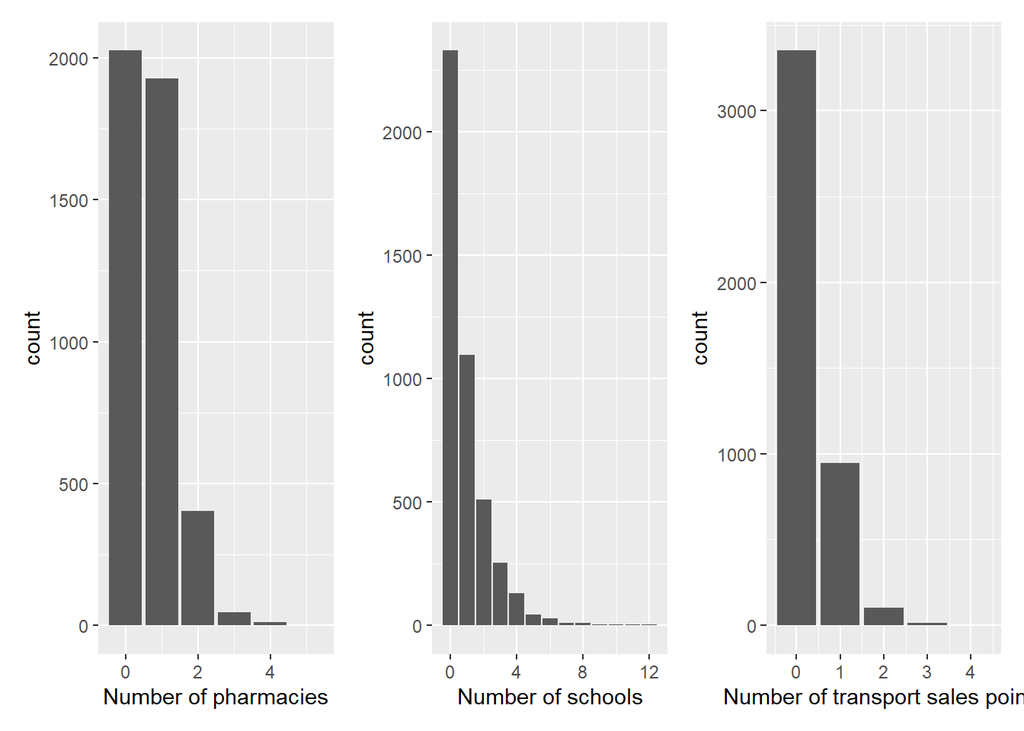

```r
p1<-ggplot(df, aes(n_pharmacies))+
  geom_bar()+
  labs(x = "Number of pharmacies")

p2<-ggplot(df, aes(n_schools))+
  geom_bar()+
  labs(x="Number of schools")

p3<-ggplot(df, aes(n_transport_salespoints))+
  geom_bar()+
  labs(x= "Number of transport sales points")

p1+p2+p3
```

The small range of values is also visible in the box plots below as the interquartile ranges are extremely close to the median. Also, the box plots show that there are some outliers which are close to the maximum values of the boxplot.

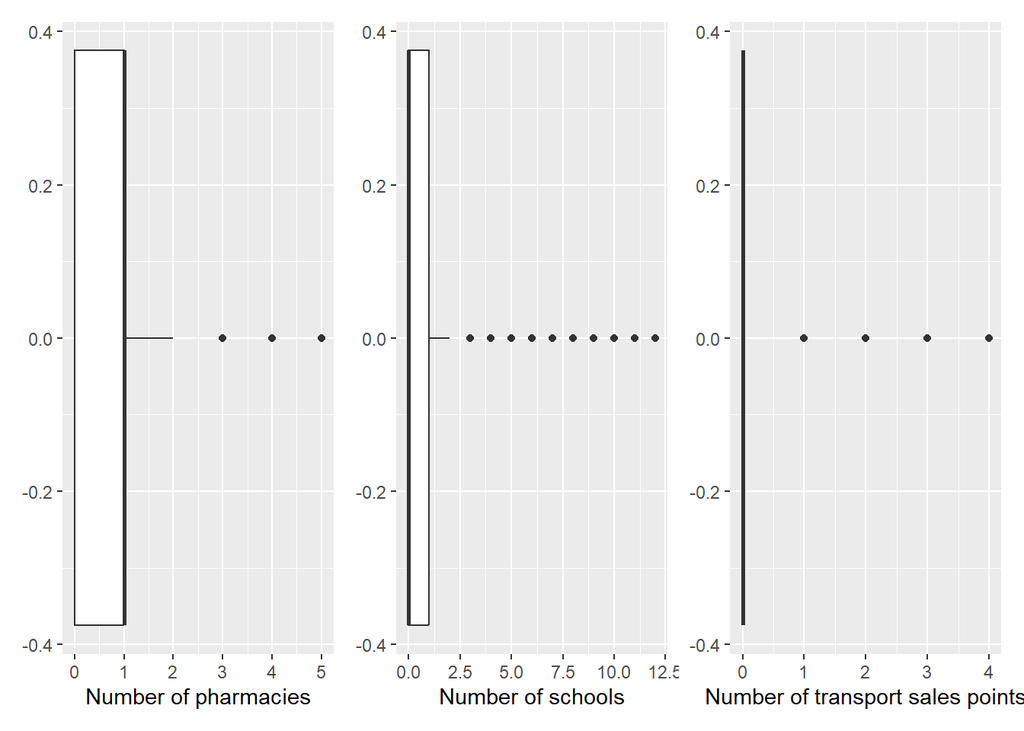

```r
p4<- ggplot(df, aes(n_pharmacies))+
geom_boxplot()+
  labs(x = "Number of pharmacies")

p5<- ggplot(df, aes(n_schools))+
geom_boxplot()+
  labs(x="Number of schools")

p6<- ggplot(df, aes(n_transport_salespoints))+
geom_boxplot()+
  labs(x= "Number of transport sales points")

p4+p5+p6
```

##### Independent variables

```r
p8<-ggplot(df, aes(population))+
geom_histogram()
p9<-ggplot(df, aes(family_income))+
geom_histogram()
p10<-ggplot(df, aes(income_per_capita))+
geom_histogram()
p11<-ggplot(df, aes(avg_age))+
geom_histogram()
p12<-ggplot(df, aes(spanish))+
geom_histogram()
p13<-ggplot(df, aes(foreigners))+
geom_histogram()
p14<-ggplot(df, aes(ratio_expense_home))+
geom_histogram()
p15<-ggplot(df, aes(pcg_num_transaction_city))+
geom_histogram()
p16<-ggplot(df, aes(city_population))+
geom_histogram()
p17<-ggplot(df, aes(population_density))+
geom_histogram()
```

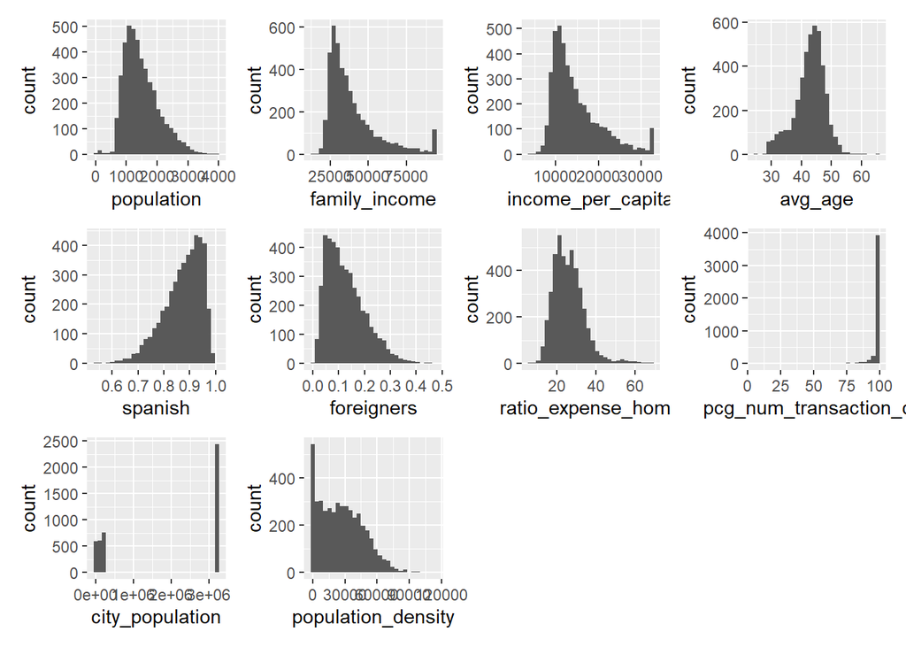

```r
p8+p9+p10+p11+p12+p13+p14+p15+p16+p17
```

#### Correlations

In this section, first the variables that do not hold explanatory variance and are therefore useless for doing regression analysis are deleted. The correlations are presented in a correlation heatmap which shows that there are rather high correlations among some of the independent variables or in other words, the data set contains multicolinearity among independent variables. As these variables contain highly overlapping information, they will together not contribute to the regression models and therefore, one of the two variables will be deleted.

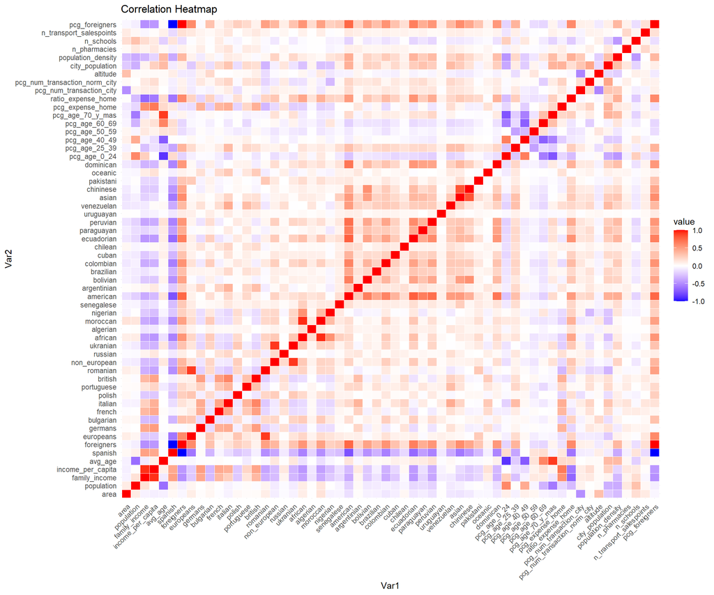

```r
df_1 <- dplyr::select_if(df, is.numeric)

df_1<- df_1 |>
dplyr::select(-census_section_code, -census_district_code, -city_code, -index, -province_code)

cor_matrix <- cor(df_1)

# Melt the correlation matrix for ggplot
melted_cor_matrix <- melt(cor_matrix)

# Create a heatmap
ggplot(melted_cor_matrix, aes(x = Var1, y = Var2, fill = value)) +
  geom_tile(color = "white") +
  scale_fill_gradient2(low = "blue", mid = "white", high = "red", midpoint = 0, limit = c(-1,1)) +
  theme_minimal() +
  theme(axis.text.x = element_text(angle = 45, hjust = 1)) +
  labs(title = "Correlation Heatmap")
```

#### Checking for multicolinearity

As the correlation heatmap indicates that the data set contains variables that are multicolinear, the extent of this multicolinearity is checked using eigenvalues and the condition number. The eigenvalues of a large portion of the data set are rather low and indicate that indeed some of the variabels are highly correlated. Also, the condition number is large again indicating multicolinearity.

```r
eigenvalues <-eigen(cor_matrix)$values
eigenvalues_rounded <-round(eigen(cor_matrix)$values,4)

eigen_df <- data.frame(
  Variable = colnames(cor_matrix),
  Eigenvalue = eigenvalues_rounded
)
eigen_df
```

```
##                         Variable Eigenvalue
## 1                           area    10.3374
## 2                     population     5.9710
## 3                  family_income     4.5757
## 4              income_per_capita     3.0405
## 5                        avg_age     2.1680
## 6                        spanish     1.8221
## 7                     foreigners     1.6526
## 8                      europeans     1.5719
## 9                        germans     1.3930
## 10                     bulgarian     1.2836
## 11                        french     1.2029
## 12                       italian     1.1255
## 13                        polish     1.0358
## 14                    portuguese     1.0062
```

[output cut: 44 more lines]

```r
condition_number <- sqrt(max(eigenvalues) / min(eigenvalues))
condition_number
```

```
## [1] 91907115
```

##### Reducing multicolinearity

Based on the correlation matrix and the eigenvalues, variables are taken out of the data set which reduced the condition number considerably. However, one should note that the new condition number still indicates multicolinearity.

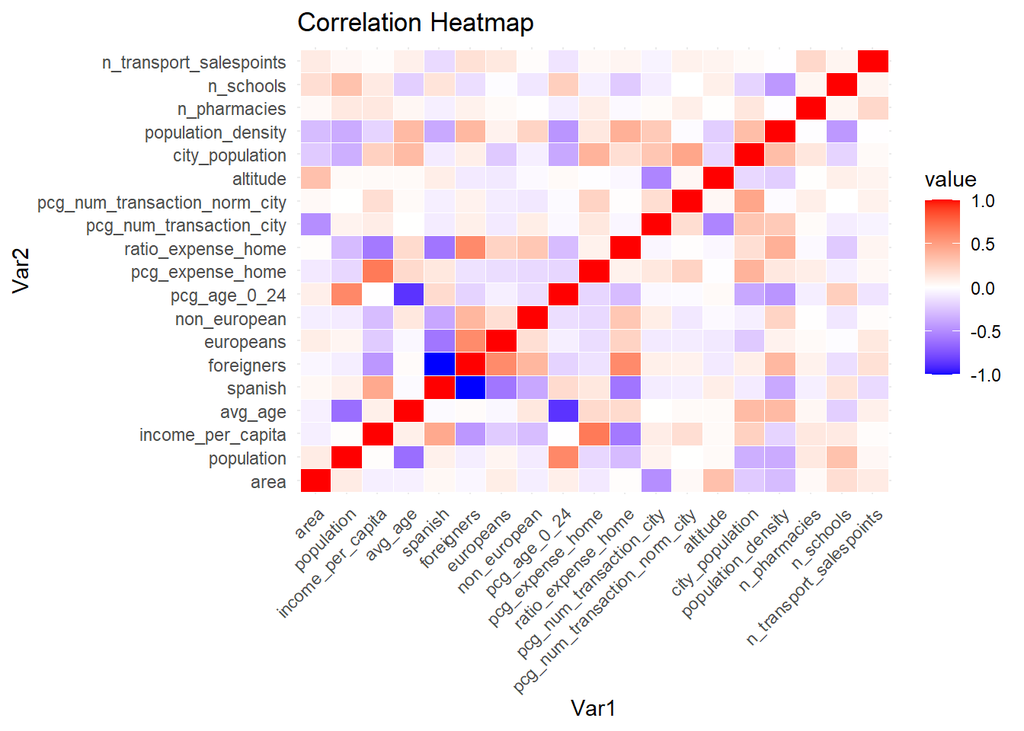

```r
df_2 <- df_1 |>
  dplyr::select(-"germans":-"romanian") |>
   dplyr::select(-"russian":-"dominican") |>
  dplyr::select(-"pcg_age_25_39":-"pcg_age_70_y_mas") |>
  dplyr::select(-"pcg_foreigners") |>
  dplyr::select(-"family_income")

#Checking correlations
cor_matrix_2 <- cor(df_2)

# Melt the correlation matrix for ggplot
melted_cor_matrix_2 <- melt(cor_matrix_2)

# Create a heatmap
ggplot(melted_cor_matrix_2, aes(x = Var1, y = Var2, fill = value)) +
  geom_tile(color = "white") +
  scale_fill_gradient2(low = "blue", mid = "white", high = "red", midpoint = 0, limit = c(-1,1)) +
  theme_minimal() +
  theme(axis.text.x = element_text(angle = 45, hjust = 1)) +
  labs(title = "Correlation Heatmap")
```

```r
eigenvalues_2 <- eigen(cor_matrix_2)$values
eigenvalues_rounded_2 <-round(eigen(cor_matrix_2)$values,4)

eigen_df_2 <- data.frame(
  Variable = colnames(cor_matrix_2),
  Eigenvalue = eigenvalues_rounded_2
)
eigen_df_2
```

```
##                         Variable Eigenvalue
## 1                           area     4.0918
## 2                     population     3.1383
## 3              income_per_capita     2.0254
## 4                        avg_age     1.7073
## 5                        spanish     1.1613
## 6                     foreigners     0.9940
## 7                      europeans     0.8926
## 8                   non_european     0.8466
## 9                   pcg_age_0_24     0.7684
## 10              pcg_expense_home     0.7149
## 11            ratio_expense_home     0.6296
## 12      pcg_num_transaction_city     0.5039
## 13 pcg_num_transaction_norm_city     0.4154
## 14                      altitude     0.3430
## 15               city_population     0.3315
## 16            population_density     0.2591
## 17                  n_pharmacies     0.1096
## 18                     n_schools     0.0673
## 19       n_transport_salespoints     0.0000
```

```r
condition_number_2 <- sqrt(max(eigenvalues_2) / min(eigenvalues_2))
condition_df <- data.frame(condition_number_full = condition_number,
                            condition_number_reduced = condition_number_2,
                           difference = condition_number - condition_number_2)
condition_df
```

```
##   condition_number_full condition_number_reduced difference
## 1              91907115                 15205674   76701442
```

### Feature engineering

In this section, all variables in the data set undergo feature engineering and are squared and cubed. Three different data sets are generated per outcome variable, excluding the feature engineered variables of that specific outcome variable.

```r
df_feature<- df_2 |>
  mutate(population2 = population^2,
         population3 = population^3,
         income_per_capita_2 = income_per_capita^2,
         income_per_capita_3 = income_per_capita^3,
         avg_age_2 = avg_age^2,
         avg_age_3 = avg_age^3,
         spanish_2 = spanish^2,
         spanish_3 = spanish^3,
         foreigners_2 = foreigners^2,
         foreigners_3 = foreigners^3,
         europeans2 = europeans^2,
         europeans3 = europeans^3,
         non_european2 = non_european^2,
         non_european3 = non_european^3,
         pcg_expense_home_2 = pcg_expense_home^2,
         pcg_expense_home_3 = pcg_expense_home^3,
         pcg_num_transaction_city_2 = pcg_num_transaction_city^2,
         pcg_num_transaction_city_3 = pcg_num_transaction_city^3,
         city_population2 = city_population^2,
         city_population3 = city_population^3,
         population_density2 = population_density^2,
         population_density3 = population_density^3,
         n_pharmacies2 = n_pharmacies^2,
         n_pharmacies3 = n_pharmacies^3,
         n_schools2 = n_schools^2,
         n_schools3 = n_schools^3,
         n_transport_salespoints2 = n_transport_salespoints^2,
         n_transport_salespoints3 = n_transport_salespoints^3)


df_pharmacies_full_feaure <- df_feature |>
 dplyr::select(-n_pharmacies2, -n_pharmacies3, -pcg_age_0_24)

df_schools_full_feature <- df_feature |>
  dplyr::select(-n_schools2, -n_schools3, -pcg_num_transaction_norm_city)

df_transport_full_feature <- df_feature |>
  dplyr::select(-n_transport_salespoints3, -n_transport_salespoints2, -pcg_age_0_24, -pcg_num_transaction_norm_city)
```

## 1. Model on number of pharmacies

In this chapter, the available data will be used to indicate what factors explain the number of pharmacies in census sections as well as whether census sections have enough or too few pharmacies.

### Feature selection I

To reduce dimenisionality, Lasso regression is applied, reducing the number of variables in the model. Lasso regression is able to shrink slopes all the way to 0 and is therefore able to make uncontributing variables disappear. The variables that are left by the lasso regression are stored in in a new data frame called df_pharmacies. Then, the correlation matrix of the independent variables and the the dependent variable: n_pharmacies is generated. One should note that these correlations are rather low. Hereafter, a robust correlation is computed to control for possible outliers affecting the correlations. The correlations maintain low. One should note that correlations are at the basis of most regression algorithms. These low correlations forecasts a final regression model with low explanability.

```r
lambda <- 10^seq(-3, 3, length = 100)

lasso <- train(
  n_pharmacies ~., data = df_2, method = "glmnet",
  trControl = trainControl("cv", number = 10),
  tuneGrid = expand.grid(alpha = 1, lambda = lambda)
)

coef(lasso$finalModel, lasso$finalModel$lambdaOpt)
```

```
## 19 x 1 sparse Matrix of class "dgCMatrix"
##                                          s1
## (Intercept)                    1.175582e+00
## area                           1.982064e-03
## population                     2.905209e-04
## income_per_capita              1.576552e-05
## avg_age                        1.224902e-03
## spanish                       -8.295802e-01
## foreigners                     .
## europeans                     -9.580670e-02
## non_european                   2.066573e+00
## pcg_age_0_24                  -1.482716e+00
## pcg_expense_home              -4.025145e-04
## ratio_expense_home             .
## pcg_num_transaction_city      -2.461900e-03
## pcg_num_transaction_norm_city -7.693760e-04
## altitude                       .
## city_population                6.549975e-08
## population_density            -1.159705e-06
## n_schools                      1.240298e-03
## n_transport_salespoints        2.103738e-01
```

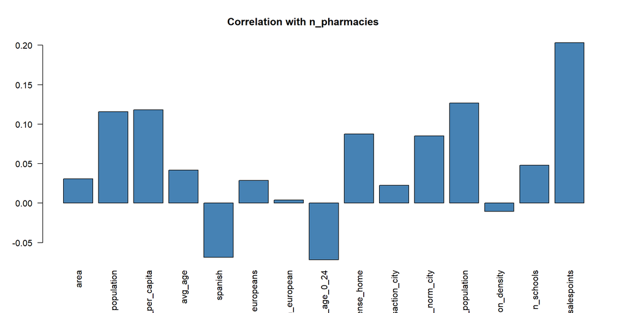

```r
lasso_coef <- coef(lasso$finalModel, s = lasso$finalModel$lambdaOpt)

non_zero_vars <- rownames(lasso_coef)[lasso_coef[, 1] != 0]
non_zero_vars <- non_zero_vars[-1]

df_pharmacies <- df_2 |>
  dplyr::select(all_of(non_zero_vars), n_pharmacies)

#Chekcing correlations -> low correlations
corr<- cor(df_pharmacies$n_pharmacies, df_pharmacies[,-"n_pharmacies"])
corr<-round(corr,4)

barplot(corr, names.arg = names(df_pharmacies[,-"n_pharmacies"]), col = "steelblue", las = 2 , adj = 0.45, main = "Correlation with n_pharmacies")
```

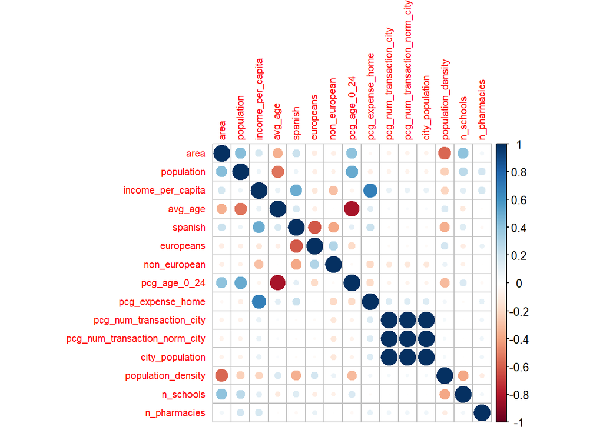

```r
#check for iqr = 0 variables to do robust corrlations
iqr_values <- apply(df_pharmacies, 2, IQR)

take_out_list<-names(iqr_values[iqr_values == 0])

#Taking out 0 IQR  and colniliarities
df_phar_corr<- df_pharmacies |>
  dplyr::select(-take_out_list) |>
  drop_na()

#Robust correlations
ccs<-cov.rob(df_phar_corr)
cor2<-cov2cor(ccs$cov)
corrplot::corrplot(cor2, number.cex = 0.4, tl.cex = 0.7)
```

### Feature selection II

In this section, a Lasso regression is performed again, this time including the feature engineered variables. The selected variables are stored in the data frame df_pharmacies_feature. Most correlations maintain fairly low.

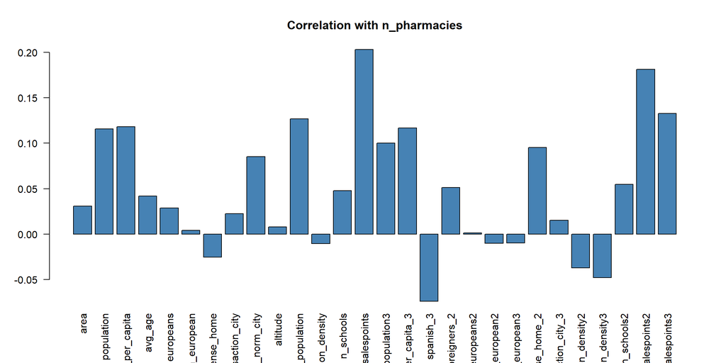

```r
lasso <- train(
  n_pharmacies ~., data = df_pharmacies_full_feaure, method = "glmnet",
  trControl = trainControl("cv", number = 10),
  tuneGrid = expand.grid(alpha = 1, lambda = lambda)
)
lasso_coef <- coef(lasso$finalModel, s = lasso$finalModel$lambdaOpt)

non_zero_vars <- rownames(lasso_coef)[lasso_coef[, 1] != 0]
non_zero_vars <- non_zero_vars[-1]

df_pharmacies_feature <- df_feature |>
  dplyr::select(all_of(non_zero_vars), n_pharmacies)

#Chekcing correlations -> low correlations
corr<- cor(df_pharmacies_feature$n_pharmacies, df_pharmacies_feature[,-"n_pharmacies"])
corr<-round(corr,4)
barplot(corr, names.arg = names(df_pharmacies_feature[,-"n_pharmacies"]), col = "steelblue", las = 2 , main = "Correlation with n_pharmacies")
```

### Setting up train and test data

The data frames df_pharmacies_feature and df_pharmacies are partitioned into train and test data sets with the train data sets containing 80% of the data and the test data sets the remaining 20%. The data frames with and without the feature engineered are partitioned to test in the next section the effect on the $R^2$ of the feature engineered variables. The train control is set to cross validation and the number of iterations to 10.

```r
set.seed(123)

training.samples <- df_pharmacies_feature$n_pharmacies |>
  createDataPartition(p = 0.8, list = FALSE)
train.data  <- df_pharmacies_feature[training.samples, ]
test.data <- df_pharmacies_feature[-training.samples, ]

training.samples_sim <- df_pharmacies$n_pharmacies |>
  createDataPartition(p = 0.8, list = FALSE)
train.data_sim  <- df_pharmacies[training.samples_sim, ]
test.data_sim <- df_pharmacies[-training.samples_sim, ]

train_control <- trainControl(method = "cv", number = 10)
```

### Regression models

#### Linear model

The linear model for the train data including the feature engineered variables and train data without these variables are computed. The linear model that includes the feature engineered variables shows a slightly higher $R^2$ and therefore the data frame including these feature engineered variables is selected to do the following regression analysis. However, one should note that the difference in $R^2$ is minimal and is most probably induced by the higher number of variables in the model including feature engineered variables.

```r
lm_model <- glm(n_pharmacies ~., data = train.data)

lm_fit <- train(n_pharmacies ~., data = train.data,
                method = "lm",
                trControl = train_control)


lm_fit_sim <- train(n_pharmacies ~., data = train.data_sim,
                method = "lm",
                trControl = train_control)


results <- resamples(list(linear = lm_fit, linear_sim = lm_fit_sim))
summary(results)
```

```
##
## Call:
## summary.resamples(object = results)
##
## Models: linear, linear_sim
## Number of resamples: 10
##
## MAE
##                 Min.   1st Qu.    Median      Mean   3rd Qu.      Max. NA's
## linear     0.5352246 0.5417450 0.5492571 0.5509985 0.5529989 0.5806122    0
## linear_sim 0.5337447 0.5439379 0.5586721 0.5581328 0.5657516 0.5883295    0
##
## RMSE
##                 Min.   1st Qu.    Median      Mean   3rd Qu.      Max. NA's
## linear     0.6302177 0.6544474 0.6678625 0.6680706 0.6832309 0.7176774    0
## linear_sim 0.6289839 0.6526017 0.6639334 0.6723684 0.6757260 0.7390888    0
##
## Rsquared
##                 Min.    1st Qu.     Median      Mean   3rd Qu.      Max. NA's
## linear     0.0675888 0.07978316 0.11131445 0.1104347 0.1353948 0.1520725    0
## linear_sim 0.0532488 0.08449089 0.09757553 0.1083823 0.1451133 0.1708907    0
```

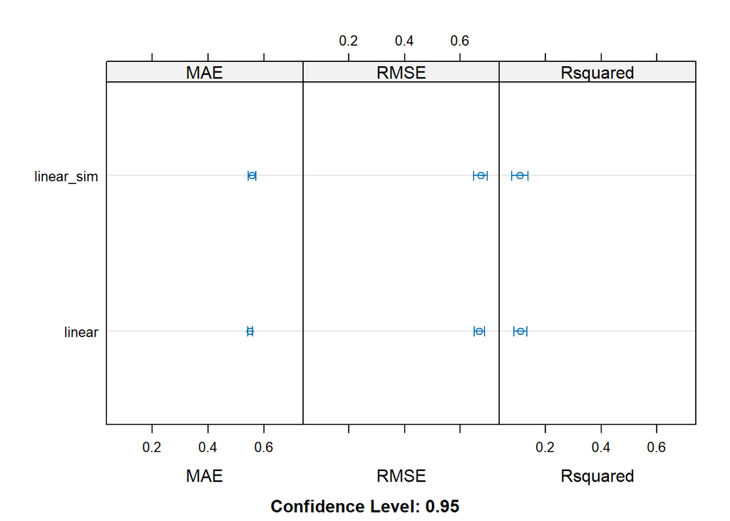

```r
dotplot(results)
```

#### Poisson

The poisson regression model is trained as this model is designed to estimate models with a non-negative discrete outcome variable which perfectly suits the ouctome variable n_pharmacies (see descriptive statistics) The poisson regression model, models lambda as a linear function of the independent variables: $[E|Y] = \lambda = exp( \alpha_0+\alpha_1x_1+\alpha_2x_2...)$. Note that the variance of Y should be equal to lambda. The poisson model does not improve the MAE, RMSE and $R^2$ considerably compared to the linear model.

```r
poisson_model <- glm(n_pharmacies ~ ., data = train.data, family = poisson )

poisson_fit <- train(n_pharmacies ~ ., data = train.data,
                     method = "glm", family = poisson,
                     trControl = train_control)

results <- resamples(list(linear = lm_fit, poisson =poisson_fit))
summary(results)
```

```
##
## Call:
## summary.resamples(object = results)
##
## Models: linear, poisson
## Number of resamples: 10
##
## MAE
##              Min.   1st Qu.    Median      Mean   3rd Qu.      Max. NA's
## linear  0.5352246 0.5417450 0.5492571 0.5509985 0.5529989 0.5806122    0
## poisson 0.5264216 0.5524931 0.5592719 0.5595129 0.5652904 0.5959361    0
##
## RMSE
##              Min.   1st Qu.    Median      Mean   3rd Qu.      Max. NA's
## linear  0.6302177 0.6544474 0.6678625 0.6680706 0.6832309 0.7176774    0
## poisson 0.6080140 0.6576732 0.6680818 0.6691106 0.6831673 0.7227646    0
##
## Rsquared
##               Min.    1st Qu.    Median      Mean   3rd Qu.      Max. NA's
## linear  0.06758880 0.07978316 0.1113144 0.1104347 0.1353948 0.1520725    0
## poisson 0.04637543 0.08027138 0.1068176 0.1111286 0.1289582 0.1940458    0
```

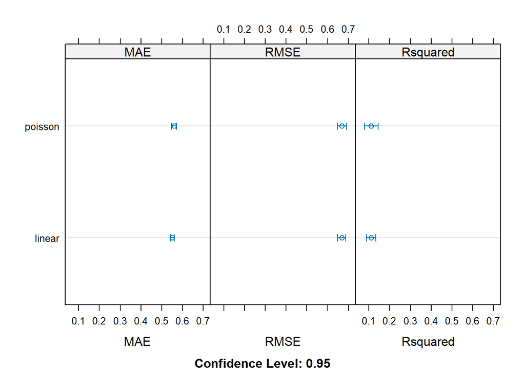

```r
dotplot(results)
```

#### Quasi-poisson regression

```r
#Checking overdispersion -> no overdispersion detected
poisson_model <- glm( n_pharmacies~ ., family = poisson, data = df_pharmacies_feature)
check_overdispersion(poisson_model)
```

```
## # Overdispersion test
##
##        dispersion ratio =    0.700
##   Pearson's Chi-Squared = 3069.971
##                 p-value =        1
```

```
## No overdispersion detected.
```

```r
quasipoisson_model <- glm(n_pharmacies ~ ., data = train.data, family = quasipoisson )


quasipoisson_fit <- train(n_pharmacies ~., data = train.data,
                     method = "glm", family = "quasipoisson",
                     trControl = train_control)


results <- resamples(list(linear = lm_fit, poisson = poisson_fit, quasipoisson = quasipoisson_fit))
summary(results)
```

```
##
## Call:
## summary.resamples(object = results)
##
## Models: linear, poisson, quasipoisson
## Number of resamples: 10
##
## MAE
##                   Min.   1st Qu.    Median      Mean   3rd Qu.      Max. NA's
## linear       0.5352246 0.5417450 0.5492571 0.5509985 0.5529989 0.5806122    0
## poisson      0.5264216 0.5524931 0.5592719 0.5595129 0.5652904 0.5959361    0
## quasipoisson 0.5415592 0.5487673 0.5570220 0.5591015 0.5686278 0.5788726    0
##
## RMSE
##                   Min.   1st Qu.    Median      Mean   3rd Qu.      Max. NA's
## linear       0.6302177 0.6544474 0.6678625 0.6680706 0.6832309 0.7176774    0
## poisson      0.6080140 0.6576732 0.6680818 0.6691106 0.6831673 0.7227646    0
## quasipoisson 0.6347447 0.6474740 0.6627024 0.6687951 0.6954345 0.7041473    0
##
## Rsquared
##                    Min.    1st Qu.    Median      Mean   3rd Qu.      Max. NA's
## linear       0.06758880 0.07978316 0.1113144 0.1104347 0.1353948 0.1520725    0
## poisson      0.04637543 0.08027138 0.1068176 0.1111286 0.1289582 0.1940458    0
## quasipoisson 0.07274136 0.09736683 0.1165093 0.1083496 0.1224693 0.1298671    0
```

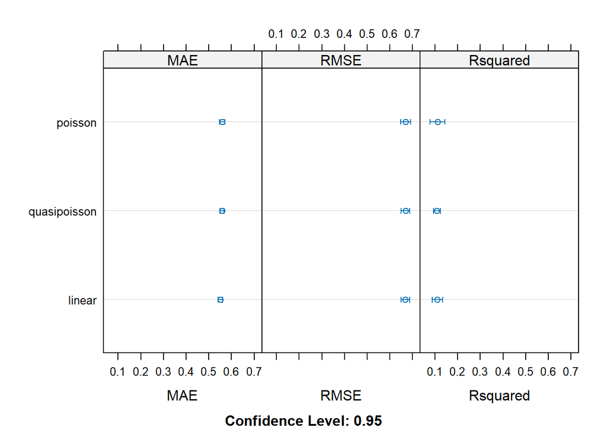

```r
dotplot(results)
```

#### Negative binomial regression analysis

```r
negbin_model <- glm.nb(n_pharmacies ~ ., data = train.data)

neg_bin_fit <- train(n_pharmacies ~., data = train.data,
                     method = "glm.nb",
                     trControl = train_control)

#Comparing all models
results <- resamples(list(linear = lm_fit, poisson = poisson_fit, quasipoisson = quasipoisson_fit, negative_binomial = neg_bin_fit))
summary(results)
```

```
##
## Call:
## summary.resamples(object = results)
##
## Models: linear, poisson, quasipoisson, negative_binomial
## Number of resamples: 10
##
## MAE
##                        Min.   1st Qu.    Median      Mean   3rd Qu.      Max.
## linear            0.5352246 0.5417450 0.5492571 0.5509985 0.5529989 0.5806122
## poisson           0.5264216 0.5524931 0.5592719 0.5595129 0.5652904 0.5959361
## quasipoisson      0.5415592 0.5487673 0.5570220 0.5591015 0.5686278 0.5788726
## negative_binomial 0.5179036 0.5509040 0.5555664 0.5555782 0.5585594 0.5864507
##                   NA's
## linear               0
## poisson              0
## quasipoisson         0
## negative_binomial    0
##
## RMSE
##                        Min.   1st Qu.    Median      Mean   3rd Qu.      Max.
## linear            0.6302177 0.6544474 0.6678625 0.6680706 0.6832309 0.7176774
## poisson           0.6080140 0.6576732 0.6680818 0.6691106 0.6831673 0.7227646
## quasipoisson      0.6347447 0.6474740 0.6627024 0.6687951 0.6954345 0.7041473
## negative_binomial 0.6314538 0.6512173 0.6637925 0.6690445 0.6759531 0.7208133
##                   NA's
## linear               0
## poisson              0
## quasipoisson         0
## negative_binomial    0
##
## Rsquared
##                         Min.    1st Qu.    Median      Mean   3rd Qu.      Max.
## linear            0.06758880 0.07978316 0.1113144 0.1104347 0.1353948 0.1520725
## poisson           0.04637543 0.08027138 0.1068176 0.1111286 0.1289582 0.1940458
## quasipoisson      0.07274136 0.09736683 0.1165093 0.1083496 0.1224693 0.1298671
## negative_binomial 0.04025325 0.09600381 0.1084862 0.1098194 0.1247049 0.1759873
##                   NA's
## linear               0
## poisson              0
## quasipoisson         0
## negative_binomial    0
```

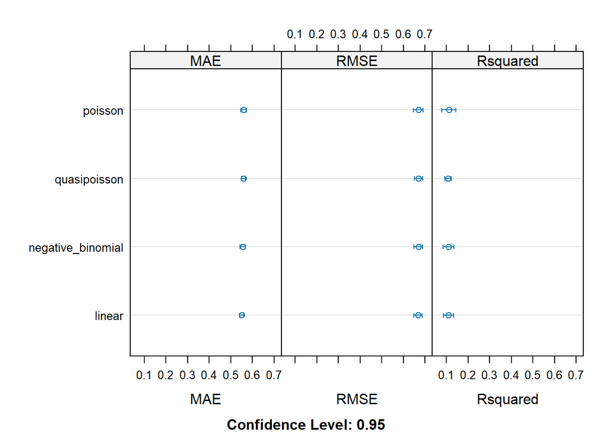

```r
dotplot(results)
```

#### Ordered logistic regression

As the outcome variable only has a limited range of discrete variables, these can be interpreted as being ordered categories. Hence, an ordered logistic regression can be utilised. As there are only few observations for 2 or more pharmacies, these are combined as n_pharmacies_cat: >2. Unfortunately, this method does not produce an MAE, RMSE and $R^2$. However, as the outcomes of these metrics were very similar fro the models above, it is difficult to choose the best method based on these metrics. Therefore, the AIC’s (Akaike Information Criterion) from the models are compared to decide on the best method. The AIC evaluates the goodness of fit of statistical model taking into account the ability to explain data as well as the complexity of the model. As the AIC function is not compatible with the train function from the ‘Caret’ package, for each method the model is computed using the ‘glm’ function to compare the AIC’s. The model with the lowest AIC is the negative binomial model. Hence, this model will be used to do the final predictions.

```r
train.data_2<- train.data |>
 mutate(n_pharmacies_cat = case_when(
            n_pharmacies ==0 ~"0",
            n_pharmacies ==1 ~"1",
            n_pharmacies >=2 ~">2")) |>
  dplyr::select(-n_pharmacies)

train.data_2$n_pharmacies_cat <- factor(
  train.data_2$n_pharmacies_cat,
  levels = c("0", "1", ">2"),
  ordered = TRUE
)

multinom_model <- multinom(n_pharmacies_cat ~ ., data = train.data_2)
```

```r
# Compare models using Achaiche information criteria (AIC)
aic_results <- AIC(lm_model, poisson_model, quasipoisson_model, negbin_model, multinom_model)

# Show results
list(AIC = aic_results)
```

```
## $AIC
##                    df      AIC
## lm_model           30 7175.286
## poisson_model      29 8722.489
## quasipoisson_model 30       NA
## negbin_model       30 6998.407
## multinom_model     58 7160.348
```

#### Validation of the best model: Negative binomial

The negative binomial model is validated by computing predictions based on the the test data. When plotting the predicted vs the actual values, the plot demonstrates that the model does not predict perfectly. Both the RMSE as well as the MSE are rather low values which indicate good model performance. As the MAE is 0.56, on average the model predictions are imprecise with 0.56 units. The RMSE value is somewhat larger as RMSE penalises large errors. The RMSE is 0.68, that is, on average the model predictions are imprecise with 0.68 units.

```r
predictions <- predict(neg_bin_fit, newdata = test.data)

summary(predictions)
```

```
##    Min. 1st Qu.  Median    Mean 3rd Qu.    Max.
##  0.1368  0.4873  0.6171  0.6602  0.8038  2.0958
```

```r
actual_values <- test.data$n_pharmacies

mae <- mean(abs(predictions - actual_values))
mae
```

```
## [1] 0.5564764
```

```r
rmse <- sqrt(mean((predictions - actual_values)^2))
rmse
```

```
## [1] 0.6784853
```

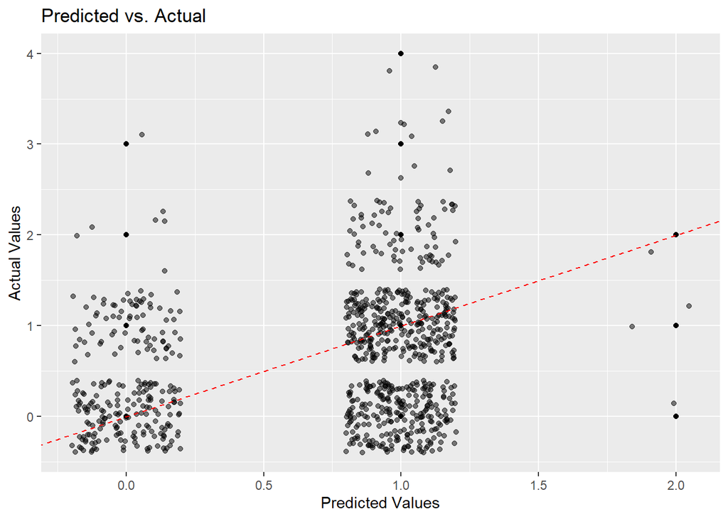

```r
rounded_predictions <- round(predictions)

ggplot(data = test.data, aes(x = rounded_predictions, y = n_pharmacies)) +
  geom_jitter(width = 0.2, alpha = 0.5)+
  geom_point() +
  geom_abline(intercept = 0, slope = 1, linetype = "dashed", color = "red") +
  labs(title = "Predicted vs. Actual",
       x = "Predicted Values",
       y = "Actual Values")
```

#### Model interpretation based on the best model: Negative binomial model

```r
neg_bin_fit_final <- train(n_pharmacies ~., data = df_pharmacies_feature,
                     method = "glm.nb",
                     trControl = train_control)
summary(neg_bin_fit_final)
```

```
##
## Call:
## NULL
##
## Coefficients:
##                                 Estimate Std. Error z value Pr(>|z|)
## (Intercept)                   -1.128e-01  3.334e-01  -0.338 0.735109
## area                           2.038e-03  1.184e-03   1.722 0.085146 .
## population                     2.373e-04  3.867e-05   6.135 8.49e-10 ***
## income_per_capita              3.685e-05  8.656e-06   4.257 2.07e-05 ***
## avg_age                        7.843e-03  2.158e-03   3.634 0.000279 ***
## europeans                     -4.977e-01  6.954e-01  -0.716 0.474178
## non_european                   4.516e+00  5.339e+00   0.846 0.397670
## ratio_expense_home             5.668e-03  2.777e-03   2.041 0.041254 *
## pcg_num_transaction_city       8.106e-03  4.160e-03   1.948 0.051381 .
## pcg_num_transaction_norm_city -7.371e-04  9.855e-04  -0.748 0.454530
## altitude                      -9.524e-05  1.223e-04  -0.779 0.435941
## city_population                3.784e-08  7.942e-09   4.765 1.89e-06 ***
## population_density             1.235e-05  2.651e-06   4.659 3.17e-06 ***
## n_schools                     -6.940e-03  1.216e-02  -0.571 0.568099
## n_transport_salespoints        7.750e-02  7.382e-02   1.050 0.293818
## population3                   -5.020e-12  3.265e-12  -1.537 0.124223
## income_per_capita_3           -1.262e-14  4.306e-15  -2.931 0.003381 **
## spanish_3                     -5.912e-01  1.681e-01  -3.517 0.000437 ***
## foreigners_2                  -1.135e+00  8.714e-01  -1.303 0.192671
## europeans2                     1.527e-01  2.695e+00   0.057 0.954826
## non_european2                 -2.229e+02  3.855e+02  -0.578 0.563147
## non_european3                  3.218e+03  7.001e+03   0.460 0.645817
## pcg_expense_home_2            -1.623e-05  7.048e-06  -2.303 0.021292 *
## pcg_num_transaction_city_3    -8.132e-07  2.650e-07  -3.069 0.002150 **
## population_density2           -3.012e-10  7.135e-11  -4.221 2.43e-05 ***
## population_density3            1.844e-15  5.582e-16   3.304 0.000954 ***
## n_schools2                     2.597e-03  1.941e-03   1.338 0.180785
## n_transport_salespoints2       5.309e-02  8.334e-02   0.637 0.524129
## n_transport_salespoints3      -1.597e-02  2.005e-02  -0.796 0.425774
## ---
## Signif. codes:  0 '***' 0.001 '**' 0.01 '*' 0.05 '.' 0.1 ' ' 1
##
## (Dispersion parameter for Negative Binomial(13988.41) family taken to be 1)
##
##     Null deviance: 3970.0  on 4413  degrees of freedom
## Residual deviance: 3572.7  on 4385  degrees of freedom
## AIC: 8716.7
##
## Number of Fisher Scoring iterations: 1
##
##
##               Theta:  13988
##           Std. Err.:  28985
## Warning while fitting theta: iteration limit reached
##
##  2 x log-likelihood:  -8656.671
```

```r
coef_summary <- coef(summary(neg_bin_fit_final))

# Exponentiating coefficients
exp_coefficients <- round(exp(coef_summary[, "Estimate"]),5)
exp_coefficients
```

```
##                   (Intercept)                          area
##                       0.89334                       1.00204
##                    population             income_per_capita
##                       1.00024                       1.00004
##                       avg_age                     europeans
##                       1.00787                       0.60791
##                  non_european            ratio_expense_home
##                      91.46981                       1.00568
##      pcg_num_transaction_city pcg_num_transaction_norm_city
##                       1.00814                       0.99926
##                      altitude               city_population
##                       0.99990                       1.00000
##            population_density                     n_schools
##                       1.00001                       0.99308
##       n_transport_salespoints                   population3
##                       1.08058                       1.00000
##           income_per_capita_3                     spanish_3
##                       1.00000                       0.55368
##                  foreigners_2                    europeans2
##                       0.32137                       1.16494
##                 non_european2                 non_european3
##                       0.00000                           Inf
##            pcg_expense_home_2    pcg_num_transaction_city_3
##                       0.99998                       1.00000
##           population_density2           population_density3
##                       1.00000                       1.00000
##                    n_schools2      n_transport_salespoints2
##                       1.00260                       1.05452
##      n_transport_salespoints3
##                       0.98416
```

```r
summary(df_pharmacies_feature$population)
```

```
##    Min. 1st Qu.  Median    Mean 3rd Qu.    Max.
##      47    1075    1381    1490    1816    4004
```

```r
summary(df_pharmacies_feature$income_per_capita)
```

```
##    Min. 1st Qu.  Median    Mean 3rd Qu.    Max.
##    3719   10580   13046   14798   17523   32242
```

```r
summary(df_pharmacies_feature$city_population)
```

```
##    Min. 1st Qu.  Median    Mean 3rd Qu.    Max.
##      47  128256 3223334 1832968 3223334 3223334
```

```r
income_per_capita_1000<-exp(0.000036849403203302837*1000)
income_per_capita_1000
```

```
## [1] 1.037537
```

```r
city_population_10.000<-exp(0.0000000378413654670*10000)
city_population_10.000
```

```
## [1] 1.000378
```

```r
negbin_model <- glm.nb(n_pharmacies ~ ., data =df_pharmacies_feature )
vif_values <- car::vif(negbin_model)
print(vif_values)
```

```
##                          area                    population
##                      1.634616                      8.441786
##             income_per_capita                       avg_age
##                     47.091849                      1.995644
##                     europeans                  non_european
##                     10.615679                     20.748417
##            ratio_expense_home      pcg_num_transaction_city
##                      7.401439                     15.505010
## pcg_num_transaction_norm_city                      altitude
##                      1.584920                      1.485279
##               city_population            population_density
##                      2.779218                     48.341246
##                     n_schools       n_transport_salespoints
##                      4.906280                     23.047083
##                   population3           income_per_capita_3
##                      7.286660                     16.942513
##                     spanish_3                  foreigners_2
##                     12.961222                      8.801520
##                    europeans2                 non_european2
##                      7.795979                     95.302898
##                 non_european3            pcg_expense_home_2
##                     40.377563                      8.935276
##    pcg_num_transaction_city_3           population_density2
##                     19.053754                    156.977496
##           population_density3                    n_schools2
##                     51.034623                      4.234203
##      n_transport_salespoints2      n_transport_salespoints3
##                    100.016762                     40.423109
```

### Score generation

A score is generated to indicate when a city has sufficient facilities and when too few. According to statista.com, Spain has an average of 4.7 pharmacies per 10.000 people. This treshold is used to indicate whether a city has sufficient, 4.7 or more pharamcies per 10.000 people, or too few pharmacies, less than 4.7 pharmacies per 10.000 people. The average number of pharmacies per 10.000 people in this data set is computed by the metric: ( n_pharmacies/population)*10000. Then, this metric is scored 0 = too few pharmacies, when the metric is below the national average of 4.7 and 1 = sufficient when the metric is equal or above the national average creating the score_pharmacies variable.

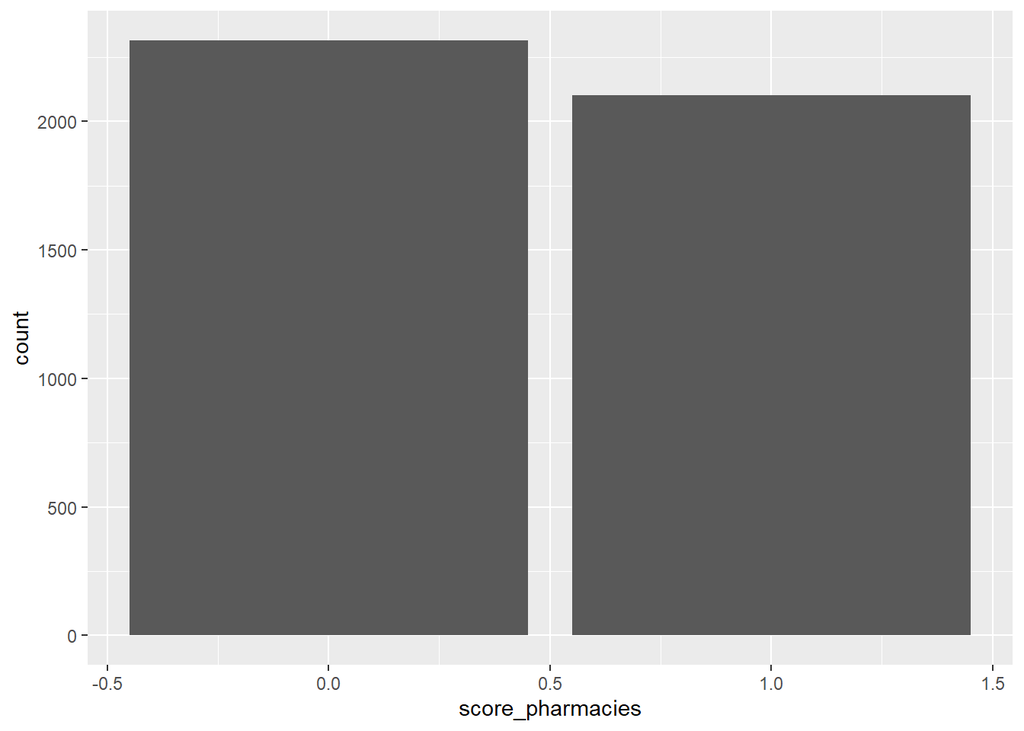

```r
#https://www.statista.com/statistics/778862/number-of-pharmacies-in-spain/#:~:text=From%202007%20to%202022%2C%20the,4.7%20pharmacies%20per%2010%2C000%20inhabitants.

df_pharmacies_feature<-df_pharmacies_feature |>
  mutate(metric = (n_pharmacies/population)*10000) |>
  mutate(score_pharmacies = if_else(metric<4.7, 0,1))


ggplot(df_pharmacies_feature, aes(score_pharmacies))+
  geom_bar()
```

### Training logistic regression

In case of a binomial outcome variable, the most common method to be applied is logistic regression. Also, as we only ave been taught this method, no other models will be trained to select the best model. However, the logistic regression is first trained with training data and later validated using testing data to be able to test model accuracy.

```r
df_pharmacies_feature_2 <- df_pharmacies_feature |>
  dplyr::select(-n_pharmacies, -metric)

training.samples <- df_pharmacies_feature_2$score_pharmacies |>
  createDataPartition(p = 0.8, list = FALSE)
train.data  <- df_pharmacies_feature_2[training.samples, ]
test.data <- df_pharmacies_feature_2[-training.samples, ]


logistic_fit_train <- glm(score_pharmacies ~., data =train.data , family = binomial)
```

#### Validating logistic regression

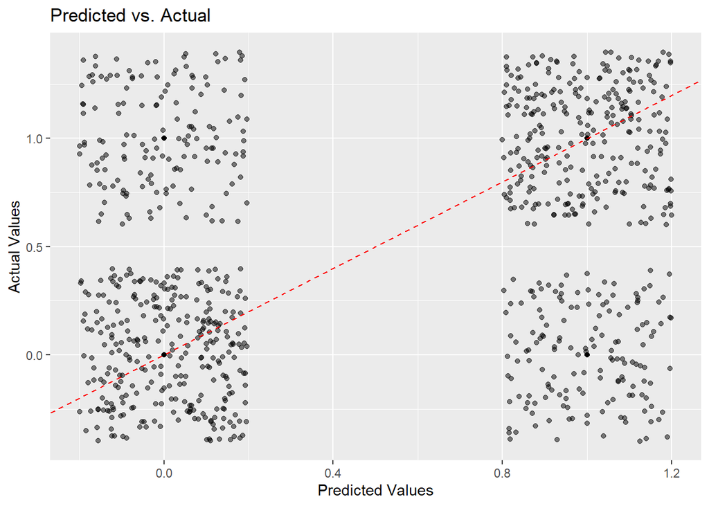

```r
# Make predictions
probabilities <- logistic_fit_train |>  predict(test.data, type = "response")
rounded_probabilities <- round(probabilities)

ggplot(data = test.data, aes(x = rounded_probabilities, y = score_pharmacies)) +
  geom_jitter(width = 0.2, alpha = 0.5)+
  geom_point() +
  geom_abline(intercept = 0, slope = 1, linetype = "dashed", color = "red") +
  labs(title = "Predicted vs. Actual",
       x = "Predicted Values",
       y = "Actual Values")
```

```r
predicted.classes <- ifelse(probabilities > 0.5, 1, 0)

table(test.data$score_pharmacies)
```

```
##
##   0   1
## 453 429
```

```r
#Confusion matrix
confusionMatrix(as.factor(test.data$score_pharmacies), as.factor(predicted.classes))
```

```
## Confusion Matrix and Statistics
##
##           Reference
## Prediction   0   1
##          0 297 156
##          1 152 277
##
##                Accuracy : 0.6508
##                  95% CI : (0.6183, 0.6823)
##     No Information Rate : 0.5091
##     P-Value [Acc > NIR] : <2e-16
##
##                   Kappa : 0.3012
##
##  Mcnemar's Test P-Value : 0.8643
##
##             Sensitivity : 0.6615
##             Specificity : 0.6397
##          Pos Pred Value : 0.6556
##          Neg Pred Value : 0.6457
##              Prevalence : 0.5091
##          Detection Rate : 0.3367
##    Detection Prevalence : 0.5136
##       Balanced Accuracy : 0.6506
##
##        'Positive' Class : 0
##
```

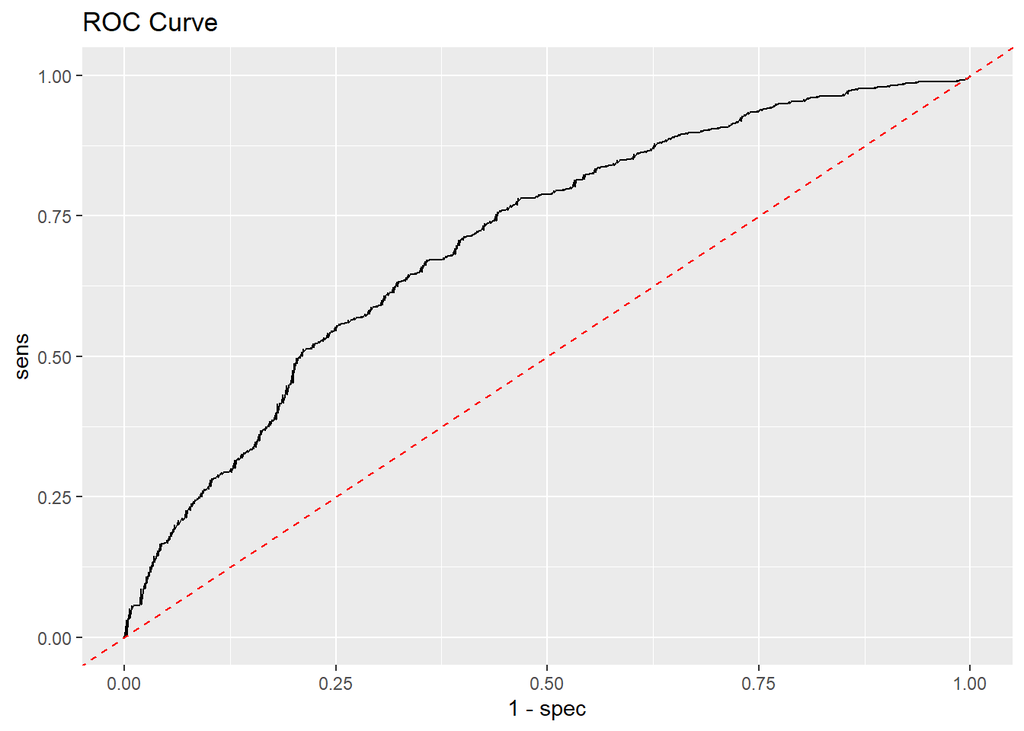

```r
#Creating roc curve
roc <- roc(as.factor(test.data$score_pharmacies), probabilities)
sens <- roc$sensitivities
spec <- roc$specificities

ggplot(data.frame(sens,spec), aes(x=1-spec, y=sens)) + geom_line()+
  geom_abline(intercept = 0, slope = 1, linetype = "dashed", color = "red")+
  labs(title = "ROC Curve")
```

#### Model interpretation and visualisation

The coefficients are exponentiated as the coefficients produced by the model are in a log scale in order to make the interpretation of the coefficients easier. The variables ‘population’, ‘income_per_capita’, ‘avg_age’, ‘pcg_num_transaction_city’, ‘city_population’, ‘population_density’, ‘population3’, ‘income_per_capita_3’, ‘spanish_3’, ‘pcg_num_transaction_city_3’, ‘population_density2’ and ‘population_density3’ have a coefficient that is statistically significantly different from 0. Only the raw significant variables are interpreted. For every person increase in population, every euro increase in ‘income_per_capita’, every year increase in ‘avg_age’, every percentage increase in ‘pcg_num_transaction_city’ and every person increase in ‘population_density’, the odds of score_pharmacies =1, that is the city has enough pharmacies, is multiplied by 1.0016, 1.0001, 1.0381, 1.0526 and 1.0001 respectively. In other words, these variabls have a positive effect on the odds of a census section having enough pharmacies. Note that again the model has a problem with multicolinearity (see VIF) and hence the coefficients are not fully reliable.

```r
logistic_fit <- glm(score_pharmacies ~., data =df_pharmacies_feature_2 , family = binomial)
summary(logistic_fit)
```

```
##
## Call:
## glm(formula = score_pharmacies ~ ., family = binomial, data = df_pharmacies_feature_2)
##
## Coefficients:
##                                 Estimate Std. Error z value Pr(>|z|)
## (Intercept)                   -5.322e+00  1.504e+00  -3.538 0.000404 ***
## area                           1.073e-02  5.497e-03   1.952 0.050893 .
## population                     1.609e-03  2.027e-04   7.934 2.12e-15 ***
## income_per_capita              1.450e-04  3.790e-05   3.825 0.000131 ***
## avg_age                        3.735e-02  9.397e-03   3.975 7.03e-05 ***
## europeans                      1.073e-03  2.947e+00   0.000 0.999710
## non_european                   2.135e+01  2.268e+01   0.941 0.346475
## ratio_expense_home             2.114e-02  1.214e-02   1.742 0.081572 .
## pcg_num_transaction_city       5.123e-02  1.942e-02   2.638 0.008349 **
## pcg_num_transaction_norm_city -3.209e-03  4.348e-03  -0.738 0.460488
## altitude                       5.037e-04  5.440e-04   0.926 0.354464
## city_population                1.775e-07  3.427e-08   5.181 2.21e-07 ***
## population_density             6.615e-05  1.162e-05   5.692 1.25e-08 ***
## n_schools                     -4.056e-02  5.310e-02  -0.764 0.444999
## n_transport_salespoints        3.655e-01  3.286e-01   1.112 0.265988
## population3                   -1.971e-10  2.147e-11  -9.180  < 2e-16 ***
## income_per_capita_3           -5.027e-14  1.869e-14  -2.690 0.007154 **
## spanish_3                     -2.107e+00  7.133e-01  -2.954 0.003133 **
## foreigners_2                  -3.005e+00  3.676e+00  -0.817 0.413669
## europeans2                    -4.485e+00  1.134e+01  -0.396 0.692387
## non_european2                 -1.488e+03  1.637e+03  -0.909 0.363429
## non_european3                  2.665e+04  2.986e+04   0.892 0.372212
## pcg_expense_home_2            -6.006e-05  3.070e-05  -1.957 0.050404 .
## pcg_num_transaction_city_3    -5.051e-06  1.206e-06  -4.187 2.83e-05 ***
## population_density2           -1.519e-09  3.106e-10  -4.890 1.01e-06 ***
## population_density3            9.119e-15  2.421e-15   3.767 0.000165 ***
## n_schools2                     1.112e-02  8.694e-03   1.279 0.200993
## n_transport_salespoints2       1.994e-01  3.747e-01   0.532 0.594555
## n_transport_salespoints3      -7.616e-02  8.876e-02  -0.858 0.390912
## ---
## Signif. codes:  0 '***' 0.001 '**' 0.01 '*' 0.05 '.' 0.1 ' ' 1
##
## (Dispersion parameter for binomial family taken to be 1)
##
##     Null deviance: 6108.7  on 4413  degrees of freedom
## Residual deviance: 5527.8  on 4385  degrees of freedom
## AIC: 5585.8
##
## Number of Fisher Scoring iterations: 5
```

```r
# Extracting coefficients using summary()
coef_summary <- coef(summary(logistic_fit))

options(scipen = 999)
# Exponentiating coefficients
exp_coefficients <- round(exp(coef_summary[, "Estimate"]),5)
exp_coefficients
```

```
##                   (Intercept)                          area
##                       0.00489                       1.01079
##                    population             income_per_capita
##                       1.00161                       1.00014
##                       avg_age                     europeans
##                       1.03806                       1.00107
##                  non_european            ratio_expense_home
##              1869537260.34085                       1.02136
##      pcg_num_transaction_city pcg_num_transaction_norm_city
##                       1.05256                       0.99680
##                      altitude               city_population
##                       1.00050                       1.00000
##            population_density                     n_schools
##                       1.00007                       0.96026
##       n_transport_salespoints                   population3
##                       1.44128                       1.00000
##           income_per_capita_3                     spanish_3
##                       1.00000                       0.12155
##                  foreigners_2                    europeans2
##                       0.04956                       0.01128
##                 non_european2                 non_european3
##                       0.00000                           Inf
##            pcg_expense_home_2    pcg_num_transaction_city_3
##                       0.99994                       0.99999
##           population_density2           population_density3
##                       1.00000                       1.00000
##                    n_schools2      n_transport_salespoints2
##                       1.01118                       1.22069
##      n_transport_salespoints3
##                       0.92667
```

```r
options(scipen = 0)

vif_values <- car::vif(logistic_fit)
print(vif_values)
```

```
##                          area                    population
##                      1.700847                      9.899211
##             income_per_capita                       avg_age
##                     45.817619                      1.834364
##                     europeans                  non_european
##                     10.494340                     22.135063
##            ratio_expense_home      pcg_num_transaction_city
##                      9.062038                     14.722084
## pcg_num_transaction_norm_city                      altitude
##                      1.670544                      1.593288
##               city_population            population_density
##                      2.687045                     52.153088
##                     n_schools       n_transport_salespoints
##                      4.526785                     25.877275
##                   population3           income_per_capita_3
##                      8.705777                     15.404153
##                     spanish_3                  foreigners_2
##                     12.677382                      8.548006
##                    europeans2                 non_european2
##                      7.849835                    102.964500
##                 non_european3            pcg_expense_home_2
##                     43.505120                      8.729023
##    pcg_num_transaction_city_3           population_density2
##                     17.592323                    183.675403
##           population_density3                    n_schools2
##                     61.411082                      3.872410
##      n_transport_salespoints2      n_transport_salespoints3
##                     97.852123                     37.011044
```

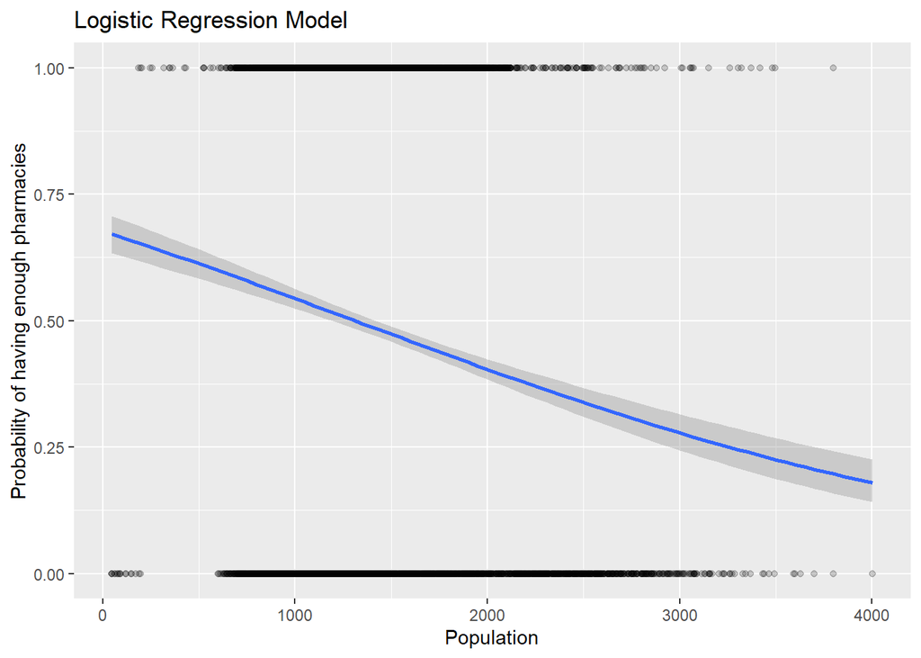

```r
#Prediction by population
df_pharmacies_feature_2|>
  ggplot(aes(population, score_pharmacies)) +
  geom_point(alpha = 0.2) +
  geom_smooth(method = "glm", method.args = list(family = "binomial")) +
  labs(
    title = "Logistic Regression Model",
    x = "Population",
    y = "Probability of having enough pharmacies"
    )
```

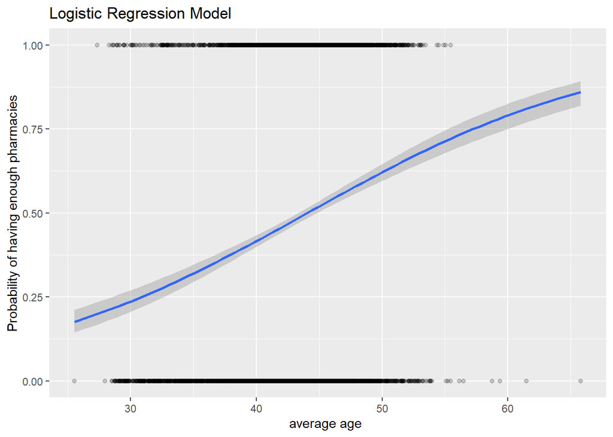

```r
#Prediction by avg_age
df_pharmacies_feature_2 |>
  ggplot(aes(avg_age , score_pharmacies)) +
  geom_point(alpha = 0.2) +
  geom_smooth(method = "glm", method.args = list(family = "binomial")) +
  labs(
    title = "Logistic Regression Model",
    x = "average age ",
    y = "Probability of having enough pharmacies"
    )
```

## 2. Model on number of schools

In this chapter, the available data will be used to indicate what factors explain the number of schools in census sections as well as whether census sections have enough or too few schools. As the steps for this analysis share a great overlap with the steps performed in the analysis of number of pharmacies, the more general explanations and reasoning behind certain steps will not be repeated, and the focus will be mainly on the interpretation of the results.

### Feature selection I

In this section feature selection based on the data frame without feature engineered variables using Lasso regression is performed. The correlation matrix shows that there are multicolinearities among some of the independent variables. The correlations of the selected variables with the dependent variable n_schools are rather low. These low correlations forecasts a final regression model with low explanability.

```r
lasso <- train(
  n_schools ~., data = df_2, method = "glmnet",
  trControl = trainControl("cv", number = 10),
  tuneGrid = expand.grid(alpha = 1, lambda = lambda)
)

#Retrieving coefficients
coef(lasso$finalModel, lasso$finalModel$lambdaOpt)
```

```
## 19 x 1 sparse Matrix of class "dgCMatrix"
##                                          s1
## (Intercept)                    1.272119e-02
## area                           1.049837e-02
## population                     4.801093e-04
## income_per_capita              1.668756e-05
## avg_age                        1.681660e-02
## spanish                       -7.069972e-01
## foreigners                     .
## europeans                     -4.542740e-01
## non_european                  -9.514043e-01
## pcg_age_0_24                   1.737489e-01
## pcg_expense_home              -1.691554e-03
## ratio_expense_home             .
## pcg_num_transaction_city       7.814647e-03
## pcg_num_transaction_norm_city -2.908803e-03
## altitude                      -5.894406e-05
## city_population               -1.594873e-10
## population_density            -2.491044e-05
## n_pharmacies                   .
## n_transport_salespoints        7.813877e-02
```

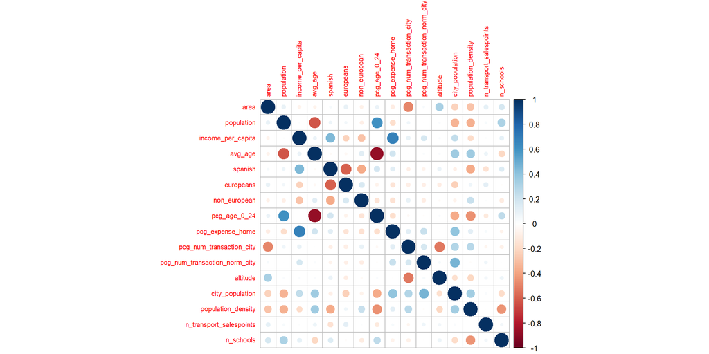

```r
# Extract coefficients for the optimal lambda
lasso_coef <- coef(lasso$finalModel, s = lasso$finalModel$lambdaOpt)

# Identify variables with non-zero coefficients and create list
non_zero_vars <- rownames(lasso_coef)[lasso_coef[, 1] != 0]
non_zero_vars <- non_zero_vars[-1]

#Keep only non zero coefficients
df_schools <- df_2 |>
  dplyr::select(all_of(non_zero_vars), n_schools)

#Chekcing correlations
corr<- cor(df_schools)
corrplot::corrplot(corr, number.cex = 0.4, tl.cex = 0.7)
```

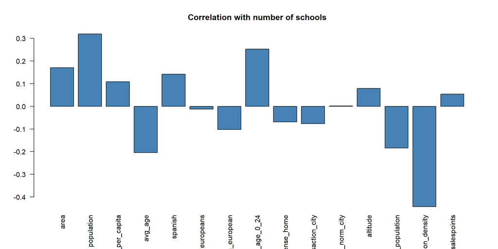

```r
#Chekcing correlations -> low correlations
corr<- cor(df_schools$n_schools, df_schools[,-"n_schools"])
corr<-round(corr,4)
barplot(corr, names.arg = names(df_schools[,-"n_schools"]), col = "steelblue", las = 2 , main = "Correlation with number of schools")
```

### Feature selection II

In this section feature selection based on the data frame with feature engineered variables is performed. The correlations of the selected variables with the dependent variable n_schools are rather low. These low correlations forecasts again a final regression model with low explanability.

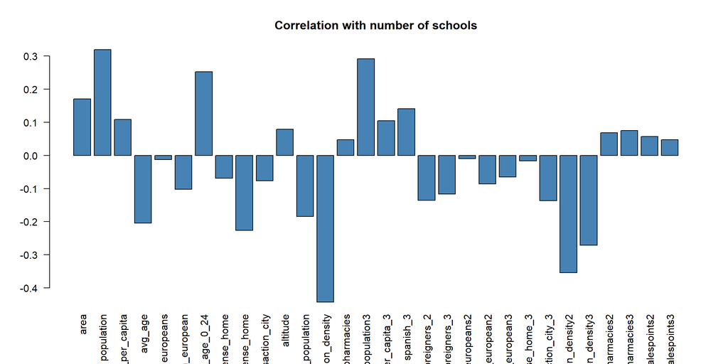

```r
df_schools_full_feature<- df_schools_full_feature |>
  drop_na()

lasso <- train(
  n_schools ~., data = df_schools_full_feature, method = "glmnet",
  trControl = trainControl("cv", number = 10),
  tuneGrid = expand.grid(alpha = 1, lambda = lambda)
)

# Extract coefficients for the optimal lambda
lasso_coef <- coef(lasso$finalModel, s = lasso$finalModel$lambdaOpt)

# Identify variables with non-zero coefficients and create list
non_zero_vars <- rownames(lasso_coef)[lasso_coef[, 1] != 0]
non_zero_vars <- non_zero_vars[-1]

#Keep only non zero coefficients
df_schools_feature <- df_schools_full_feature |>
  dplyr::select(all_of(non_zero_vars), n_schools)

#Chekcing correlations -> low correlations
corr<- cor(df_schools_feature$n_schools, df_schools_feature[,-"n_schools"])
corr<-round(corr,4)
barplot(corr, names.arg = names(df_schools_feature[,-"n_schools"]), col = "steelblue", las = 2 , main = "Correlation with number of schools")
```

### Setting up test and train data

```r
set.seed(456)
training.samples <- df_schools_feature$n_schools |>
  createDataPartition(p = 0.8, list = FALSE)
train.data  <- df_schools_feature[training.samples, ]
test.data <- df_schools_feature[-training.samples, ]

training.samples_sim <- df_schools$n_schools |>
  createDataPartition(p = 0.8, list = FALSE)
train.data_sim  <- df_schools[training.samples_sim, ]
test.data_sim <- df_schools[-training.samples_sim, ]

train_control <- trainControl(method = "cv", number = 10)
```

### Regression models

#### Linear model

The linear model including the feature engineered variables shows a slightly higher $R^2$ and therefore the data frame including these feature engineered variables is selected to do the following regression analysis. However, one should note that the difference in $R^2$ is minimal and is most probably induced by the higher number of variables in the model including feature engineered variables.

```r
lm_model <- lm(n_schools ~ ., data = train.data)

lm_fit <- train(n_schools ~., data = train.data,
                method = "lm",
                trControl = train_control)

lm_fit_sim <- train(n_schools ~., data = train.data_sim,
                method = "lm",
                trControl = train_control)

results <- resamples(list(linear = lm_fit, linear_sim = lm_fit_sim))
summary(results)
```

```
##
## Call:
## summary.resamples(object = results)
##
## Models: linear, linear_sim
## Number of resamples: 10
##
## MAE
##                 Min.   1st Qu.    Median      Mean   3rd Qu.      Max. NA's
## linear     0.7388637 0.7780836 0.7958169 0.8000162 0.8262313 0.8530391    0
## linear_sim 0.7739206 0.8165948 0.8430226 0.8364374 0.8562432 0.8809296    0
##
## RMSE
##                Min.  1st Qu.   Median     Mean  3rd Qu.     Max. NA's
## linear     1.027414 1.074339 1.157614 1.157029 1.210491 1.309635    0
## linear_sim 1.103921 1.138646 1.167124 1.184887 1.231913 1.297212    0
##
## Rsquared
##                 Min.   1st Qu.    Median      Mean   3rd Qu.      Max. NA's
## linear     0.1866502 0.2414745 0.2521090 0.2553811 0.2822443 0.2965758    0
## linear_sim 0.1950646 0.2108766 0.2360641 0.2303079 0.2487299 0.2625218    0
```

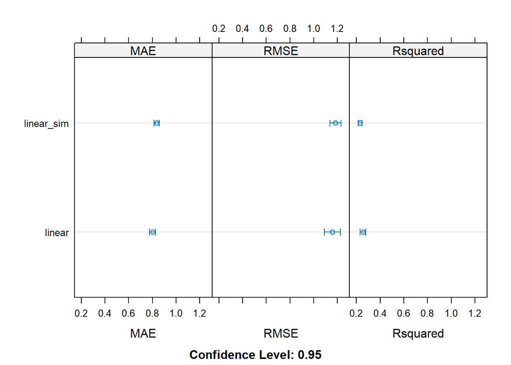

```r
dotplot(results)
```

#### Poisson

The first model being trained is the poisson regression model. This model is designed to estimate models with a non-negative discrete outcome variable [see Poisson chapter 1 for more information]. The poisson model does not improve the MAE, RMSE and $R^2$ considerably compared to the linear model.

```r
poisson_model <- glm(n_schools ~ ., data = train.data, family = poisson )

poisson_fit <- train(n_schools ~ ., data = train.data,
                     method = "glm", family = poisson,
                     trControl = train_control)


results <- resamples(list(linear = lm_fit, poisson =poisson_fit))
summary(results)
```

```
##
## Call:
## summary.resamples(object = results)
##
## Models: linear, poisson
## Number of resamples: 10
##
## MAE
##              Min.   1st Qu.    Median      Mean   3rd Qu.      Max. NA's
## linear  0.7388637 0.7780836 0.7958169 0.8000162 0.8262313 0.8530391    0
## poisson 0.7501700 0.7877976 0.7923042 0.8020006 0.8222439 0.8521699    0
##
## RMSE
##             Min.  1st Qu.   Median     Mean  3rd Qu.     Max. NA's
## linear  1.027414 1.074339 1.157614 1.157029 1.210491 1.309635    0
## poisson 1.054537 1.077967 1.131866 1.155562 1.225359 1.341139    0
##
## Rsquared
##              Min.   1st Qu.    Median      Mean   3rd Qu.      Max. NA's
## linear  0.1866502 0.2414745 0.2521090 0.2553811 0.2822443 0.2965758    0
## poisson 0.1919249 0.2326186 0.2425947 0.2569867 0.2632714 0.3594517    0
```

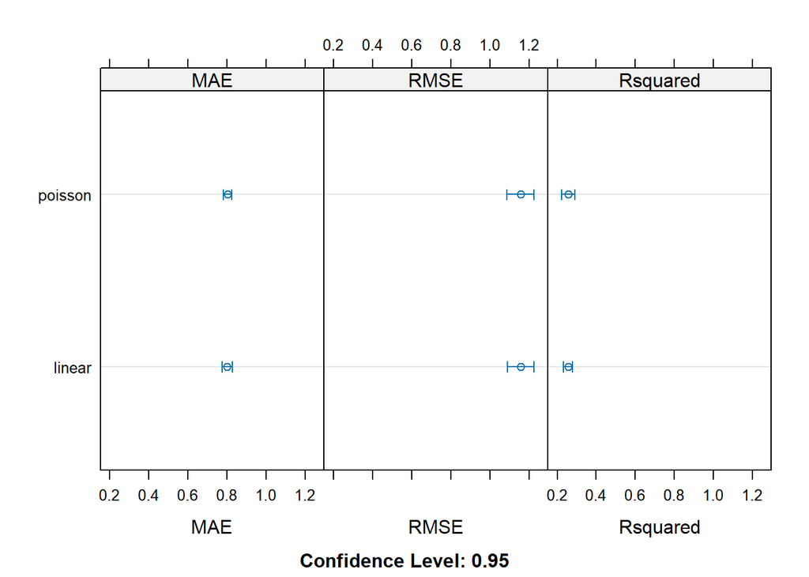

```r
dotplot(results)
```

#### Quasi-poisson regression

A possible issue for the poisson model is when the variance is significantly larger than the mean and overdispersion occurs. The quasi-poisson model is able to combat this as it assumes that variance can be modeled as a linear function of the mean and computes an overdispersion factor $\phi$ relating to the mean and variance: $Var(Y) = \phi * mean(Y)$ Hence, overdispersion is checked using the poisson model and overdispersion was detected. Again the quasi- poisson model does not improve the MAE, RMSE and $R^2$ considerably compared to the former two models.

```r
#Checking overdispersion -> Overdispersion detected
poisson_model <- glm( n_schools~ ., family = poisson, data = df_schools_feature)
check_overdispersion(poisson_model)
```

```
## # Overdispersion test
##
##        dispersion ratio =    1.282
##   Pearson's Chi-Squared = 5617.638
##                 p-value =  < 0.001
```

```
## Overdispersion detected.
```

```r
quasipoisson_model <- glm(n_schools ~ ., data = train.data, family = quasipoisson )

quasipoisson_fit <- train(n_schools ~., data = train.data,
                     method = "glm", family = "quasipoisson",
                     trControl = train_control)

results <- resamples(list(linear = lm_fit, poisson = poisson_fit, quasipoisson = quasipoisson_fit))
summary(results)
```

```
##
## Call:
## summary.resamples(object = results)
##
## Models: linear, poisson, quasipoisson
## Number of resamples: 10
##
## MAE
##                   Min.   1st Qu.    Median      Mean   3rd Qu.      Max. NA's
## linear       0.7388637 0.7780836 0.7958169 0.8000162 0.8262313 0.8530391    0
## poisson      0.7501700 0.7877976 0.7923042 0.8020006 0.8222439 0.8521699    0
## quasipoisson 0.7194762 0.7727813 0.8097356 0.8022936 0.8329004 0.8946334    0
##
## RMSE
##                   Min.  1st Qu.   Median     Mean  3rd Qu.     Max. NA's
## linear       1.0274144 1.074339 1.157614 1.157029 1.210491 1.309635    0
## poisson      1.0545371 1.077967 1.131866 1.155562 1.225359 1.341139    0
## quasipoisson 0.9847411 1.060611 1.179393 1.154201 1.246178 1.309706    0
##
## Rsquared
##                   Min.   1st Qu.    Median      Mean   3rd Qu.      Max. NA's
## linear       0.1866502 0.2414745 0.2521090 0.2553811 0.2822443 0.2965758    0
## poisson      0.1919249 0.2326186 0.2425947 0.2569867 0.2632714 0.3594517    0
## quasipoisson 0.1928618 0.2293394 0.2753596 0.2577976 0.2863041 0.2992745    0
```

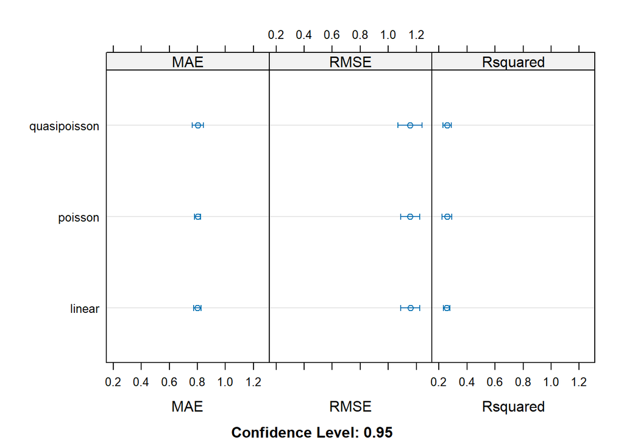

```r
dotplot(results)
```

#### Negative binomial regression analysis

The negative binomial model is again an algorithm that compensates for overdispersion by adding an overdispersion factor $\phi$ relating to the mean and variance: $Var(Y) = mean (Y) +\phi * mean(Y)^2$ . Again the negative model does not improve the MAE, RMSE and $R^2$ considerably compared to the former models.

```r
negbin_model <- glm.nb(n_schools ~ ., data = train.data)

neg_bin_fit <- train(n_schools ~., data = train.data,
                     method = "glm.nb",
                     trControl = train_control)


results <- resamples(list(linear = lm_fit, poisson = poisson_fit, quasipoisson = quasipoisson_fit, negative_binomial = neg_bin_fit))
summary(results)
```

```
##
## Call:
## summary.resamples(object = results)
##
## Models: linear, poisson, quasipoisson, negative_binomial
## Number of resamples: 10
##
## MAE
##                        Min.   1st Qu.    Median      Mean   3rd Qu.      Max.
## linear            0.7388637 0.7780836 0.7958169 0.8000162 0.8262313 0.8530391
## poisson           0.7501700 0.7877976 0.7923042 0.8020006 0.8222439 0.8521699
## quasipoisson      0.7194762 0.7727813 0.8097356 0.8022936 0.8329004 0.8946334
## negative_binomial 0.7724624 0.7797595 0.7898651 0.7942866 0.7999722 0.8382156
##                   NA's
## linear               0
## poisson              0
## quasipoisson         0
## negative_binomial    3
##
## RMSE
##                        Min.  1st Qu.   Median     Mean  3rd Qu.     Max. NA's
## linear            1.0274144 1.074339 1.157614 1.157029 1.210491 1.309635    0
## poisson           1.0545371 1.077967 1.131866 1.155562 1.225359 1.341139    0
## quasipoisson      0.9847411 1.060611 1.179393 1.154201 1.246178 1.309706    0
## negative_binomial 1.0342454 1.122849 1.144812 1.154300 1.199527 1.256293    3
##
## Rsquared
##                        Min.   1st Qu.    Median      Mean   3rd Qu.      Max.
## linear            0.1866502 0.2414745 0.2521090 0.2553811 0.2822443 0.2965758
## poisson           0.1919249 0.2326186 0.2425947 0.2569867 0.2632714 0.3594517
## quasipoisson      0.1928618 0.2293394 0.2753596 0.2577976 0.2863041 0.2992745
## negative_binomial 0.1987308 0.2451940 0.2615987 0.2613166 0.2780975 0.3223038
##                   NA's
## linear               0
## poisson              0
## quasipoisson         0
## negative_binomial    3
```

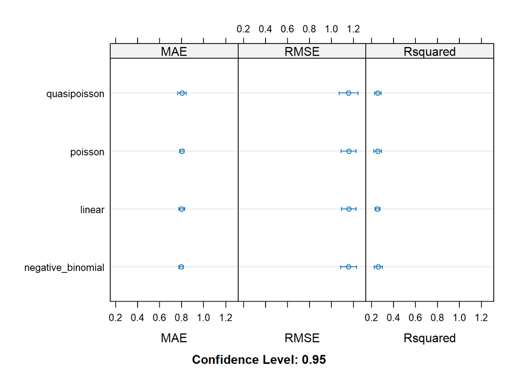

```r
dotplot(results)
```

#### Zero-inflated poisson model

The zero-inflated poisson model combats the issue of an outcome variable with a large number of zeros in comparison with the rest of the values. This model is able to predict the zeros by using logistic regression whereas for the non zero values it uses poisson regression. Unfortunately, this method does not produce an MAE, RMSE and $R^2$. However, as the outcomes of these metrics were very similar fro the models above, it is difficult to choose the best method based on these metrics. Therefore, the AIC’s (Akaike Information Criterion) from the models are compared to decide on the best method. The model with the lowest AIC is the negative binomial model. Hence, this model will be used to do the final predictions.

```r
zeroinfl_model <- zeroinfl(n_schools ~., data =  train.data)

# Compare models using Achaiche information criteria (AIC)
aic_results <- AIC(lm_model, poisson_model, quasipoisson_model, negbin_model, zeroinfl_model)
# Show results
list(AIC = aic_results)
```

```
## $AIC
##                    df       AIC
## lm_model           32 11067.663
## poisson_model      31 10358.823
## quasipoisson_model 32        NA
## negbin_model       32  8201.385
## zeroinfl_model     62  8468.614
```

#### Validation of the best model: Negative binomial

The negative binomial model is validated by computing predictions based on the the test data. When plotting the predicted vs the actual values, the plot demonstrates that the model does not predict perfectly. Both the RMSE as well as the MSE are rather low values which indicate good model performance. As the MAE is 0.79, on average the model predictions are imprecise with 0.79 units. The RMSE value is somewhat larger as RMSE penalises large errors. The RMSE is 1.13, that is, on average the model predictions are imprecise with 1.13 units.

```r
predictions <- predict(neg_bin_fit, newdata = test.data)

summary(predictions)
```

```
##     Min.  1st Qu.   Median     Mean  3rd Qu.     Max.
## 0.006976 0.339001 0.686084 0.899522 1.313492 3.272851
```

```r
actual_values <- test.data$n_schools


mae<- mean(abs(predictions - actual_values))
mae
```

```
## [1] 0.7901638
```

```r
rmse <- sqrt(mean((predictions - actual_values)^2))
rmse
```

```
## [1] 1.128325
```

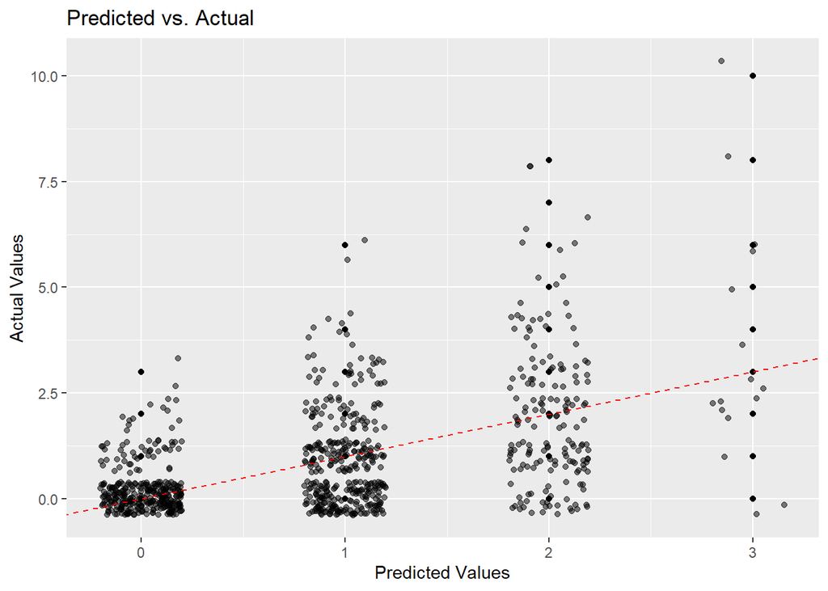

```r
rounded_predictions <- round(predictions)

ggplot(data = test.data, aes(x = rounded_predictions, y = n_schools)) +
  geom_jitter(width = 0.2, alpha = 0.5)+
  geom_point() +
  geom_abline(intercept = 0, slope = 1, linetype = "dashed", color = "red") +
  labs(title = "Predicted vs. Actual",
       x = "Predicted Values",
       y = "Actual Values")
```